# Coursework Report

*N* removed NAs: 2

*N* removed typo: 1

*N* removed <18: 17

[output not shown]

**Main analysis results**

*t*(128) = 10.94, *p* < .001

[interactive chart not shown]

[figure not shown]

[interactive chart not shown]

# Coursework Report

Analysing Data, Spring 2020

# Aim

The study aimed to find out whether color had an effect on womans attractiveness ratings of men in a replication of experiment 1 in Elliot et al (2010)

# Hypothesis

Viewing a picture of a moderately attractive man in a red frame will have increase perceptions of male attractiveness.

## Methods

### Participants

Summary of Participant Demographics by Age and Condition

| Condition | N | *M*<sub>age</sub> | *SD*<sub>age</sub> |
| --- | --- | --- | --- |
| control | 66 | 21.00 | 2.14 |
| experimental | 65 | 20.86 | 2.02 |

### Design

Participants viewed the same monochrome portrait of a man as in Elliot et al. (2010) on one of two backgrounds. The control condition viewed the picture on a white background (n = 66), whilsts the experimental condition (n = 65) viewed the picture on a red background. After viewing the photograph participants were asked questions relating to their perceptions of the mans attractiveness.

### Measures

Measures of perceived attractiveness were assessed through the same three questions relating to the photograph as Elliot et al. (2010). The questions were as follows: “How attractive do you think this person is?”, “How pleasant is this person to look at?” and “If I were to meet this person in this picture face to face, I would think he is attractive?.” Each question was scored on a 9 points scale, ranging from 1, being to lowest possible rating of attractiveness, to 9, being the highest possible rating of attractiveness. In adition, following Elliot et al. (2010), after collecting ratings from all 3 questions, each score was averaged to form a composite score for each condition (illustrated in figure)

*Figure 2* summary of mean attractiveness ratings by condition

| Condition | Count | *M* | *SD* |
| --- | --- | --- | --- |
| control | 66 | 6.88 | 1.23 |
| experimental | 65 | 5.41 | 1.29 |

The figure shows the apparent difference in mean attraction ratings between the control(white) and the experimental (red) conditions, with the control having a higher composite score.

# Results

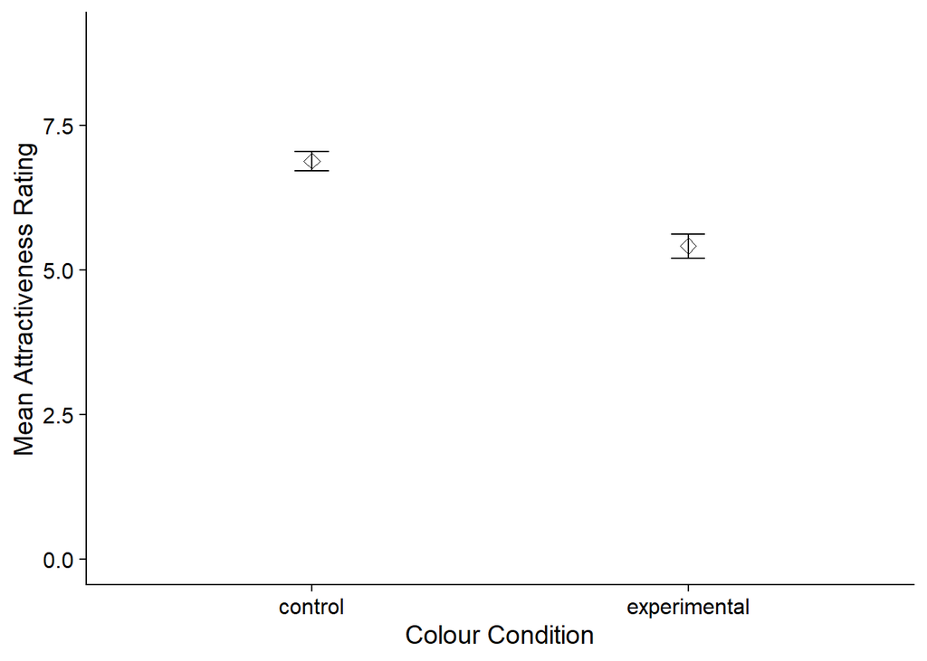

# Discussion

Results from our experiment contradicted our original hypothesis, as the colour red did not seem to have a significant effect on increasing ratings of perceived attraction. Rather, the colour white seemed to have a significant effect on increasing perceived ratings of attraction. These findings also contradict the original results from Elliot’s et al (2010) first experiment, from which the current experimental design was replicated, which suggested the colour red had a significant effect on perceptions of attraction. However, it is important to note that the current study was not an exact replication, as the sample size was significantly higher (*n* = 131) than in the original study (*n* = 21) . Nonetheless, other studies replicating Elliot’s et al (2010) experiment 1 design, as well as examining the effect the colour red has on attraction, have also contributed to the body of evidence contradicting the initial findings of Elliot et al (2010).

The current study shares findings with Peperkoorn, Roberts, & Pollet (2016) and (Hesslinger, Goldbach, Carbon, 2016), in that the colour red has no effect on attraction. However, this study indicates that the colour white has a positive effect on attraction. There is no current research that further suggests the colour white has a significant effect on perceptions of attraction. Thus it seems, due to the contradictory nature of studies exploring the effect the colour red has on attraction, in addition to the results presented in the current study, more research is needed to truly understand the effect colour has on perceptions of attraction. This study also fails to consider the cultural implications of how colour may affect perceptions of phsyical attraction. Further studies investigating this may provide further insight into our understanding of colours effect on attraction.

# References

Elliot, A., Niesta Kayser, D., Greitemeyer, T., Lichtenfeld, S., Gramzow, R., Maier, M., & Liu, H. (2010). Red, rank, and romance in women viewing men. *Journal Of Experimental Psychology: General*, 139(3), 399-417. doi: 10.1037/a0019689

Francis, G. (2013). Publication bias in “Red, rank, and romance in women viewing men,” by Elliot et al. (2010). *Journal Of Experimental Psychology: General*, 142(1), 292-296. doi: 10.1037/a0027923

Hesslinger, V., Goldbach, L., & Carbon, C. (2015). Men in red: A reexamination of the red-attractiveness effect. *Psychonomic Bulletin & Review*, 22(4), 1142-1148. doi: 10.3758/s13423-015-0866-8

Peperkoorn, L., Roberts, S., & Pollet, T. (2016). Revisiting the Red Effect on Attractiveness and Sexual Receptivity. *Evolutionary Psychology*, 14(4), 147470491667384. doi: 10.1177/1474704916673841